# analysis of discrete data project notebook: separation problem

# Problem setting

There are two main reasons which may lead to a logistic regression’s parameters being non-identifiable (Gelman, Hill, and Vehtari, 2021, p. 256): * **collinearity**, that is linear association between predictor values, does not allow us to obtain separate estimates of the individual parameters $\beta_1, ..., \beta_n$; * **separation problem** which will be our focus

## Logistic regression

Logistic regression is a generalized linear model for binary data. It models the conditional distribution of $Y$, a random vector composed of dichotomous observations $(y_1, ...y_n) \in \{0,1\}$, given $X$, a vector of co-variate variables $(x_i, ...,x_n)$, as a Bernoulli distribution, or $Binomial(1, \pi)$.

$$y_i|x_i \sim \text{Binomial}(1, \pi_i)$$
Where $\pi_i$ is assumed to be a function of a linear component a linear component, $\alpha + \beta X_i$, which is modeled using a logit link function.

$$g(\pi_i) = logit \: \pi_i = log \: \frac{\pi_i}{1 - \pi_i} = \alpha + \beta x$$

Notice that the inverse function allows us to map any real number produced by the linear predictor on to $(0,1)$.

$$Pr(Y=1|X) = logit^{-1} \pi_i = \frac{e^{\alpha + \beta x}}{1 + e^{\alpha + \beta x}}$$

### Maximum likelihood estimation

For now we will assume that $X \sim N(0,1)$ so that we can drop the intercept from the equations. The maximum likelihood estimation is derived from the product of the probability density function of $Y|X$ for each $(x_1, x_2, ..., x_n)$.

$$f(y|\beta, X) = \prod_{i=1}^n \pi_i^{y_i} (1-\pi_i)^{1-{y_i}}$$

The likelihood function estimates the likelihood of observing $y$ given fixed values of $\beta$.

$$L(\beta|x1, ..., x_n) = \prod_{i=1}^N \pi_i^{y_i} (1-\pi_i)^{1-{y_i}}$$
Which we can log and simplify so as to obtain the log-likelihood function.

$$l(\beta|x1, ..., x_n) = log \: L(\beta|x1, ..., x_n ) \\
= \sum_{i=1}^n y_i \: log \: \pi_i + (1-y_i) \: log \: (1-\pi_i) \\
= \sum_{i=1}^n y_i \: log (\frac{e^{\beta x_i}}{1 + e^{\beta x_i}}) + (1-y_i) \: log(\frac{1}{1 + e^{ \beta x_i}}) \\
= \sum_{i=1}^n y_i(\beta x_i) - log(1 + e^{\beta x_i})$$

To find the MLE find the first derivative with respect to beta (with a negative second derivative) which equals 0.

$$\frac{\partial \: l(\beta|x1, ..., x_n)}{\partial \beta} = \sum_{i=1}^n y_i x_i - \pi_ix_i = \sum_{i=1}^nx_i(y_i - \pi_i) \overset{\text{set}}= 0$$

There is no close form solution. This maximization problem needs to be solved numerically. The most popular numerical method is the Newton-Raphson algorithm.

…

# The separation problem

- **complete separation**

Complete separation occurs in the sample if there is a vector of parameter values
$$\beta = (\beta_1, ..., \beta_n)$$
which partitions the explanatory value at $T$ in such a way that in one side the dependent variable is always $y_i = 1$ and on the other it is always $y_i = 0$ (see Albert and Anderson (1984))

$$\beta x_i > T \: \text{whenever} \: y_i = 1,\\
\beta x_i < T \: \text{whenever} \: y_i = 0$$

$$y_i \sim Binomial(1, \pi_x)\\
\pi_x = \frac{e^{\alpha +5x_i}}{1 + e^{\alpha + 5x_i}} \\
\alpha = 0$$

```r
### function for generating logistic regression data
logistic_sim <- function(n = 100, beta = 0.5, seed = NULL){

  ####################################################################################################################
  ### simulate population data for a logistic regression y|x ~ logit^{-1} \pi(x)
  # model details:
      # y|x ~ Binomial(1, \pi) \\
      # \pi = logit^{-1} \pi = \frac{exp(\alpha + \beta X)}{1 + exp(\alpha + \beta X)} \\
      # X ~ N(0,1) \\
      # \alpha = 0
  # n: int; size of the population data to simulate.
  # beta: numerical; true beta parameter value used to generate the population data, i.e. \pi for y ~ Binomial(1, \pi)
  # seed: int; random seed user defined
  #####################################################################################################################

    ### simulate population data
  if (length(seed) == 0) {

    random_seed <- sample(.Random.seed, 1)

  } else {

    random_seed <- seed

  }
  alpha <- 0 # centered data
  df <- tibble(x = rnorm(n, 0, 1)) %>%
    mutate(pi = plogis((alpha + beta * x)),
           y = rbinom(n, 1, prob = pi),
           random_seed = random_seed)

  return(df)
}
```

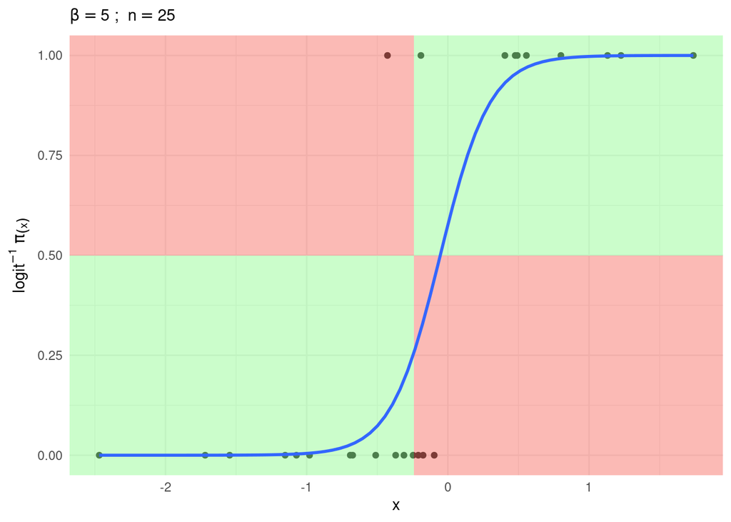

```r
make_separation_plot <- function(n = 100, beta = 0.5, seed = 1234) {

  df <- logistic_sim(n = n, beta = beta, seed = seed)

  p <- df %>%
    ggplot(aes(x = x, y = y)) +
    geom_point() +
    annotate("rect", xmin = -Inf, xmax = mean(df$x), ymin = -Inf, ymax = .5, fill = "palegreen", alpha = 0.5) +
    annotate("rect", xmin = mean(df$x), xmax = Inf, ymin = -Inf, ymax = .5, fill = "#F8766D", alpha = 0.5)  +
    annotate("rect", xmin = -Inf, xmax = mean(df$x), ymin = Inf, ymax = .5, fill = "#F8766D", alpha = 0.5) +
    annotate("rect", xmin = mean(df$x), xmax = Inf, ymin = Inf, ymax = .5, fill = "palegreen", alpha = 0.5) +
    stat_smooth(method = "glm",
                method.args = list(family = "binomial"),
                se = FALSE) +
    labs(subtitle = bquote(beta == .(beta) ~ "; " ~ n == .(n)),
         y = bquote(logit^-1 ~pi[(x)]))

  return(p)
}

p <- make_separation_plot(n = 25, beta = 5, seed = 123)
p
```

- **quasi complete separation**

$$\beta x_i \geq T \: \text{whenever} \: y_i = 1 \\
\beta x_i \leq T \: \text{whenever} \: y_i = 0$$

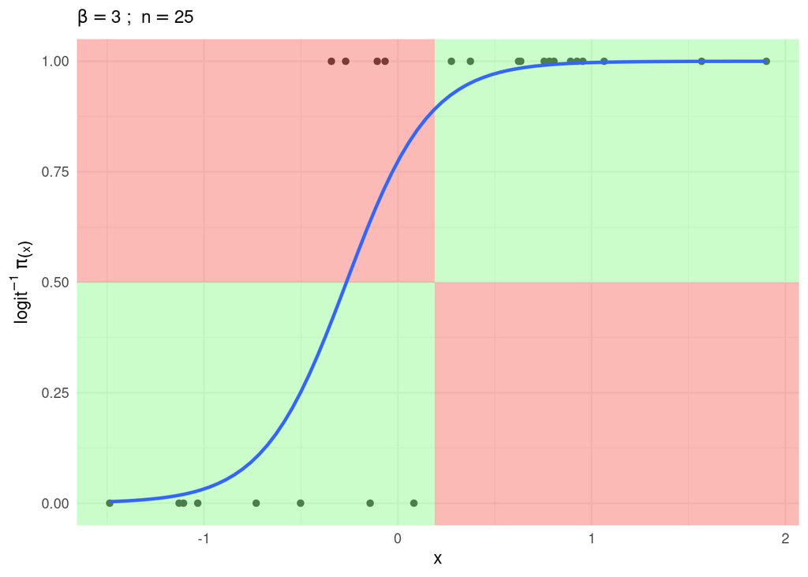

```r
p <- make_separation_plot(n = 25, beta = 3, seed = 123)
p
```

- **Factors influencing**
- small and sparse datasets;
- strength of the linear association;
- multicollinearity (Zeng and Zeng 2019)

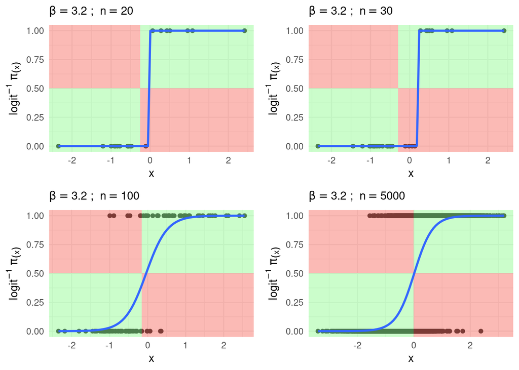

```r
logistic_sim <- function(n = 100, beta = 0.5, seed = 1234){

  set.seed(seed)
  alpha <- 0 # centered data
  df <- tibble(x = rnorm(n, 0, 1)) %>%
    mutate(pi = plogis((alpha + beta * x)), ## P(Y = 1| X) = logit^-1 \pi_i = \frac{exp(\alpha + x * \beta)}{1 + exp(\alpha + x * \beta)}
           y = rbinom(n, 1, prob = pi))

  return(df)
}

n <- c(20, 30, 100, 5000)
plots <- map(n, ~make_separation_plot(n = .x, beta = 3.2, seed = 1234))
cowplot::plot_grid(plotlist = plots)
```

- **samples with complete separation do not have MLEs**

For now we will assume that $X \sim N(0,1)$ so that we can drop the intercept from the equations. The maximum likelihood estimation is derived from the product of the probability density function of $Y|X$ for each $(x_1, x_2, ..., x_n)$.

$$f(y|\beta, X) = \prod_{i=1}^n \pi_i^{y_i} (1-\pi_i)^{1-{y_i}}$$

The likelihood function estimates the likelihood of observing $y$ given fixed values of $\beta$.

$$L(\beta|x1, ..., x_n) = \prod_{i=1}^N \pi_i^{y_i} (1-\pi_i)^{1-{y_i}}$$

To find the MLE find the first derivative with respect to beta (with a negative second derivative) which equals 0.

$$\frac{\partial \: l(\beta|x1, ..., x_n)}{\partial \beta} = \sum_{i=1}^n y_i x_i - \pi_ix_i = \sum_{i=1}^nx_i(y_i - \pi_i) \overset{\text{set}}= 0$$

There is no close form solution. This maximization problem needs to be solved numerically. The most popular numerical method is the Newton-Raphson algorithm.

```
## [1] 5
## [1] 5
```

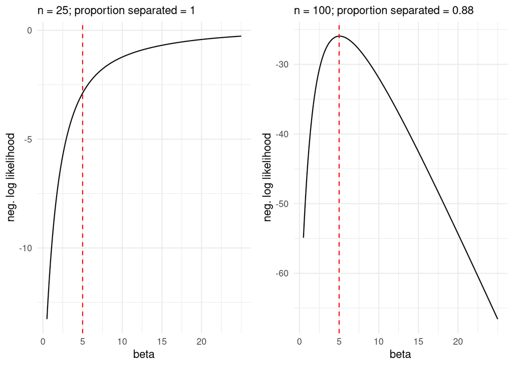

```r
plot_compare_likelihoods_n <- function (beta, n, up_to = 20){

  ## Define the negative log likelihood function
  logl <- function(beta,x,y){
    y <- y
    x <- as.matrix(x)
    loglik <- sum(-y*log(1 + exp(-(x%*%beta))) - (1-y)*log(1 + exp(x%*%beta)))
    ## turn to df
    out <- tibble(loglikelihood = loglik,
             x = x,
             beta = beta,
             y = y) %>%
      mutate(overlap = if_else((x * beta > 0 & y == 1) | (x * beta < 0 & y == 0), 1, 0))
    return(out)
  }

  plot_list <- list()
  for (i in 1:length(n)) {
    b <- beta
    s <- n[i]
    print(b)
    ## generate the data given the beta
    d <- logistic_sim(beta = b, n = s, seed = 123)
    ## copute the log likelihood and make the plit
    df <-  map_df(seq(from = 0.5, to = b + up_to, by = 0.1), ~ logl(x = d$x, y = d$y, beta = .x))
    p <- df %>%
      ggplot(aes(beta, loglikelihood)) +
      geom_line() +
      geom_vline(xintercept = b, color = "red", linetype = "dashed") +
      scale_x_continuous(breaks = seq(from = 0, to = up_to, by = 5)) +
      labs(y = "neg. log likelihood",subtitle = paste0("n = ", s, "; proportion separated = ", sum(df$overlap)/nrow(df)))

    plot_list[[i]] <- p

  }

  return(plot_list)

}
cowplot::plot_grid(plotlist = plot_compare_likelihoods_n(beta = 5, n = c(25, 100)))
```

# Proposed solutions

One solution to the problem often used by researchers is just removing the covariate with infinite MLE. However, while we do not assume that the true parameter is infinity, there tend strongly associated with the independent variable. Below I look into some solution put forward by the literature.

## frequentist approaches

### “exact”(-like) logistic regression

As separation problems, implies that MLE goes to infinity, exact logistic regressions uses the conditional likelihood of the model. In the bivariate problem at hand, that means treating the intercept as a nuisance parameter (see Hosmer Jr, Lemeshow, and Sturdivant 2013, 398:387 ff.) and condition it on the sufficient statistic of the observed value $n_1 = \sum_{i=1}^{n}y_i$. Resulting in the following conditional likelihood

$$P(Y = y_1, ..., Y = y_n|n_1) = \frac{e^{\sum_{i=1}^n y_ix_i\beta_j}}{\sum_R (\sum_{i=1}^n e^{y_ix_i\beta_j})} \:; \: \text{where} \: R = {n\choose n_1}$$
For most instances, this problems is very computationally intense. We can approximate it using MCMC sampling so as to find the median.

We will resort to one implemention of exact-like logistic regression in R using the erlm package (Zamar et al., n.d.)

## Bayesian approaches

### Weakly informative priors

#### Gelman et al (2008)

#### Ghosh et al (2015)

Albert, Adelin, and John A Anderson. 1984. “On the Existence of Maximum Likelihood Estimates in Logistic Regression Models.” *Biometrika* 71 (1): 1–10.

Hosmer Jr, David W, Stanley Lemeshow, and Rodney X Sturdivant. 2013. *Applied Logistic Regression*. Vol. 398. John Wiley & Sons.

Zamar, David, Brad McNeney, Jinko Graham, and others. n.d. “Elrm: Software Implementing Exact-Like Inference for Logistic Regression Models.”

Zeng, Guoping, and Emily Zeng. 2019. “On the Relationship Between Multicollinearity and Separation in Logistic Regression.” *Communications in Statistics-Simulation and Computation*, 1–9.